# Twitter/X Data Practice

DACSS631/COMM408

2024-09-16

## What are we doing here?

This is a practice script (in R Markdown format) on Twitter/X data. We’ll start with a code demonstration, accompanied by guiding questions to facilitate the learning process. Following this, we’ll dive into coding challenges—which I prefer to call hackathons!

# Task 1: Load the data

You can import either a local file or a cloud-hosted file using a URL.

```r
library(readr) # load the R library for data import
df <- read_csv("covidvaccine.csv") # the covid vaccine tweets. Make sure this .CSV file is in the working directory
```

**Q1: The code will create an R object named *df*, which is a dataframe. Open df to check the number of columns and rows it contains.**

# Task 2: Explore the dataframe

Experiment with the following lines of code and try to guess what each one does. If you want to find out the answer, type and run ? followed by the function name (for example, ?colnames()) to access the help documentation. Alternatively, you can always ask an AI chatbot for assistance!

```r
colnames(df)
unique(df$user_location)
sort(df$date)
typeof(df$text)
summary(df$user_followers)
```

**Q2: Which column contains the tweet text?**

**Q3: What is the earliest date in the dataframe**

**Q4: Who is the most followed user in the dataframe**

# Task 3: Data wrangling

## Find posts/tweets in a dataframe by a keyword

```r
library(dplyr)

df$text <- tolower(df$text) # convert all text to lower-case

keyword_df <- df %>% # filter tweets by a keyword
  filter(grepl("globalist",text))
```

**Q5: Which column points to the tweet text?**

**Q6: What is the name of the new dataframe which includes only tweets that contain the key term ‘globalist’?**

**Q7: How many tweets/posts contain the key term ‘globalist’?**

## Subset the dataframe by conditions

```r
influencer_posts <- df[df$user_followers>=1000000,] #select tweets sent by users with more than 1,000,000 followers

influencer_posts <- df[df$user_followers>=1000000,c("text","user_followers","user_name","user_description")] ##select tweets sent by users with more than 1,000,000 followers and retain only the four columns in the new dataframe
```

**Q8: How many tweets/posts are sent by users with more 1,000,000 followers?**

**Q9: What is this comma (after *df$user_followers>=1000000*) doing here?**

# Task 4: Save the data externally

## save the dataframe as an .csv file

```r
write.csv(influencer_posts, file="saved-influencer_posts.csv") ### save the new df as CSV files
```

## save the dataframe or multiple files as an .rda file

```r
save(influencer_posts,keyword_df, file="saved_posts.rda") ### save multiple files as a single .rda file - recommended!
load(file="saved_posts.rda") #use this code to load the saved .rda file
```

CSV files are more ‘portable’ meaning that it can be opened by different programs (e.g., Google Spreadsheet, Excel, etc.). But you may encounter encoding problems when your csv files contain special or foreign characters, such as emojis. To prevent this, it is best to save it as a .rda file, which can be easily loaded into R.

**Q10: The .csv or .rda file will be saved by default in your working directory. Do you know where your working directory is, and can you locate the file there?**

# Task 5: A quick visualization

## Use ggplot2 and ggthemes to create a static plot.

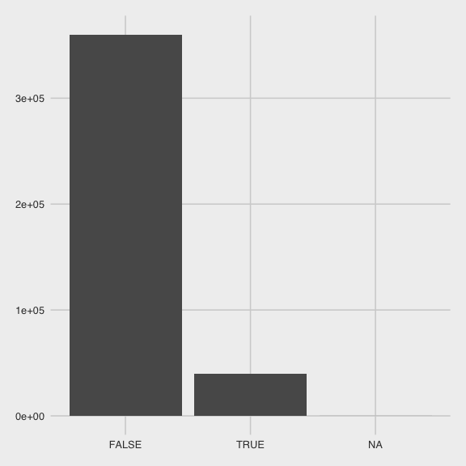

```r
library(ggplot2)
library(ggthemes)

### Create a bar plot
## show the distribution of verified/unverified users in the COVID Vaccine tweets

ggplot(data = df, aes(x = user_verified)) +
  geom_bar()+
  theme_fivethirtyeight()
```

**Q11: Based on the code above, which column in the dataframe is visualized here?**

**Q12: Are most tweets/posts sent by unverified users?**

# Task 6: A visualization of top locations in user bios

**An optional task for COMM students, but required for DACSS students.**

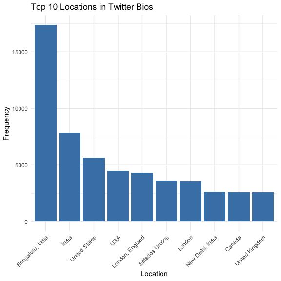

```r
library(ggplot2)
library(ggthemes)

location_frequency <- as.data.frame(table(df$user_location))

# Rename columns
colnames(location_frequency) <- c("location", "count")

# Sort by frequency and select top 10 locations
top_10_locations <- head(location_frequency[order(-location_frequency$count), ], 10)

# Plot the top 10 locations
ggplot(top_10_locations, aes(x = reorder(location, -count), y = count)) +
  geom_bar(stat = "identity", fill = "steelblue") +
  labs(title = "Top 10 Locations in Twitter Bios", x = "Location", y = "Frequency") +
  theme_minimal() +
  theme(axis.text.x = element_text(angle = 45, hjust = 1))
```